# Supplementary Material Section A: Community Detection Algorithms

2025-06-10

```r
library(MASS)
### MASS::mvrnorm(), generate multivariate normal samples
library(matlib)
### matlib::symMat(), create a symmetric matrix from a vector
library(ICONS)
### ICONS::dense() and ICONS::plotMatrix(), extract subnetwork and heatmap plot

#############################
### Loading the functions ###
#############################

BLOCK_HADAMARD_PRODUCT <- function(A, B, p_vec){
  K <- length(p_vec)
  COL_temp <- c()
  for(k in 1 : K){
    ROW_temp <- c()
    for(kp in 1 : K){
      if(k == kp){
        ROW_temp <- cbind(ROW_temp, A[k, k] * diag(p_vec[k]) + B[k, k] * matrix(1, p_vec[k], p_vec[k]))
      } else{
        ROW_temp <- cbind(ROW_temp, B[k, kp] * matrix(1, p_vec[k], p_vec[kp]))
      }
    }
    COL_temp <- rbind(COL_temp, ROW_temp)
  }
  M <- COL_temp
  return(M)
}
```

We include a toy simulation study to illustrate the implementation of the $K$-medoids and SICERS algorithms.

#### Step 1

We first construct a population covariance matrix $\Sigma_{200 \times 200}$ with $S = 200$ features, comprising $G = 3$ communities and $L_0 = 100$ singleton features, as illustrated in Figure A. The community sizes are $L_1 = L_2 = 30$ and $L_3 = 40$. For singleton features, the diagonal entries of the covariance matrix are set to $1$.

```r
n <- 50
### sample size
l_vec <- c(30, 30, 40)
### the known partition-size vector
l0 <- 100
### the number of singletons
R <- sum(l_vec)
S <- R + l0

A_0 <- diag(c(0.1, 0.2, 0.3))
B_0 <- symMat(c(0.9, - 0.430920, -0.353572, 0.8, - 0.333474, 0.7))
Sigma_0 <- matrix(0, S, S)
Sigma_0[1 : R, 1 : R] <- BLOCK_HADAMARD_PRODUCT(A_0, B_0, l_vec)
Sigma_0[(R + 1) : S, (R + 1) : S] <- diag(l0)
```

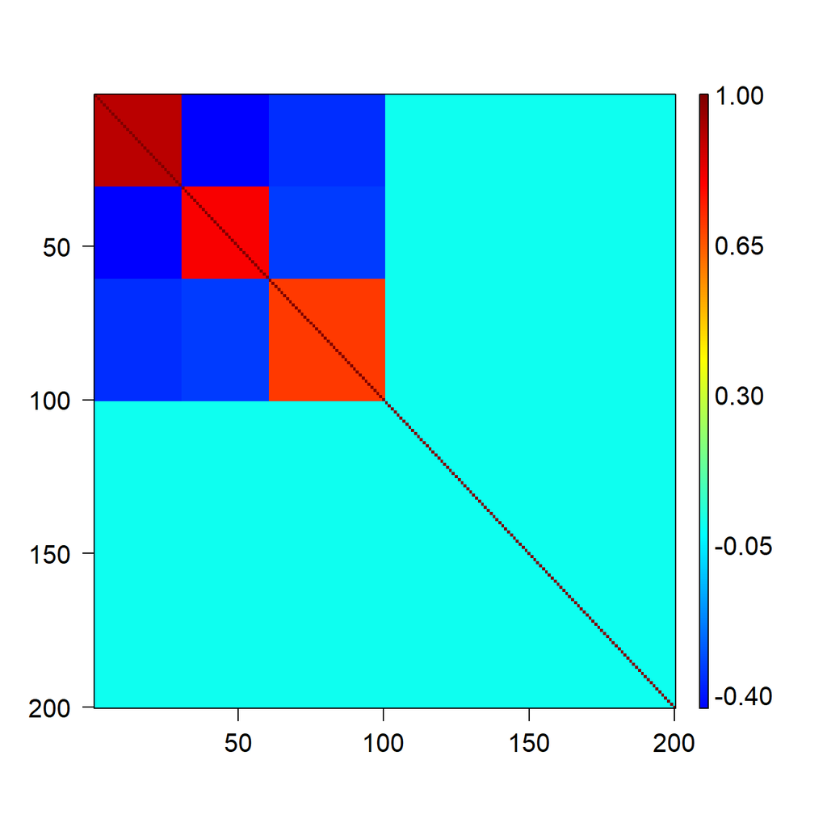

Figure A: the heatmap of the population covariance matrix (ground truth) with community sizes of $30, 30, 40$, alongside $100$ singletons.

```r
plotMatrix(z = Sigma_0, cex.axis = 1.3, cex.lab = 1.3, save.image = F)
```

```r
### heatmap of the true covariance matrix based on covariates 1 to S
```

#### Step 2

Next, we generate a multivariate normal dataset $\textbf{X}_{50 \times 200} ^ *$ from $N(\textbf{0}_{200 \times 1}, \Sigma)$ with a sample size of $n = 50$. The sample covariance matrix based on $\textbf{X}_{50 \times 200} ^ *$ is shown in Figure B. We then randomly permute the order of the $200$ features using the function in R, resulting in a permuted dataset denoted by $\widetilde{\textbf{X}}_{50 \times 200} ^ *$. The corresponding sample covariance matrix, based on $\widetilde{\textbf{X}}_{50 \times 200} ^ *$, is shown in Figure C, which appears markedly different from the heatmap A due to the feature permutation. This representation in the heatmap C probably resembles the patterns often observed in practice, where the true community structure is obscured.

```r
set.seed(20251)
data_mat <- mvrnorm(n = n, mu = rep(0, S), Sigma = Sigma_0)
### n by S
var_name <- paste("Var", seq(S), sep = "_")
colnames(data_mat) <- var_name
set.seed(20252)
name_order <- sample.int(n = S, size = S, replace = FALSE)
data_perm_mat <- data_mat[, name_order]

S_mat <- cov(data_mat)
### S by S
S_perm_mat <- cov(data_perm_mat)
### S by S
```

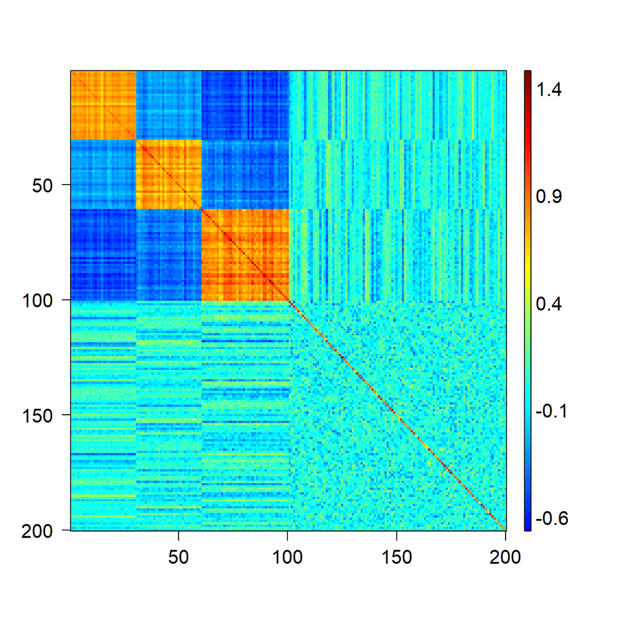

Figure B: the heatmap of the sample covariance matrix, based on features $1$ to $200$ and a sample size of $50$.

```r
plotMatrix(z = S_mat, cex.axis = 1.3, cex.lab = 1.3, save.image = F)
```

```r
### heatmap of the sample covariance matrix based on covariates 1 to S
```

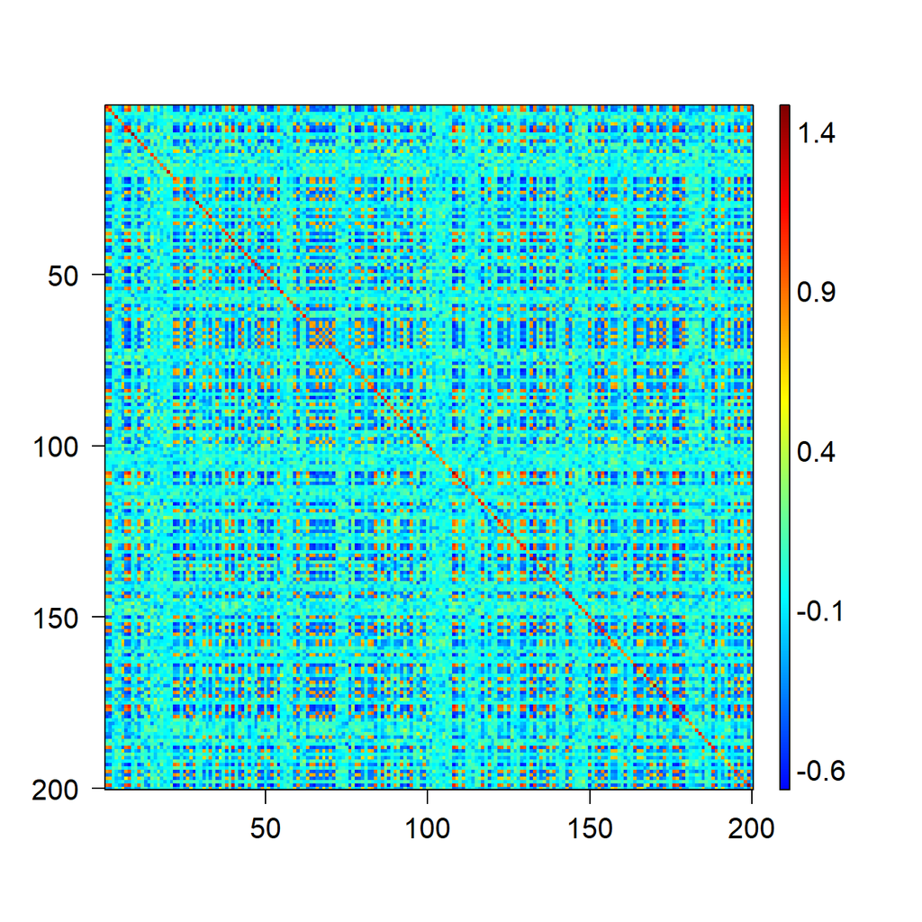

Figure C: the heatmap of the sample covariance matrix, based on the same dataset as in B, but with randomly permuted features.

```r
plotMatrix(z = S_perm_mat, cex.axis = 1.3, cex.lab = 1.3, save.image = F)
```

```r
### heatmap of the sample covariance matrix based permuted covariates
```

#### Step 3

Our objective is to recover the underlying community and singleton structure from the permuted dataset $\widetilde{\textbf{X}}_{50 \times 200} ^ *$ and its sample covariance heatmap C. To this end, we apply two methods: the $K$-medoids and SICERS methods.

```r
### applying k-mean functions to data ###
set.seed(20253)
result_kmeans <- kmeans(x = t(data_perm_mat), centers = 4)
table(result_kmeans$cluster)
```

```
##
##   1   2   3   4
##  40  30 100  30
```

```r
data_kmeans <- cbind(
    data_perm_mat[, result_kmeans$cluster == 1],
    data_perm_mat[, result_kmeans$cluster == 2],
    data_perm_mat[, result_kmeans$cluster == 4],
    data_perm_mat[, result_kmeans$cluster == 3])
S_mat_est_kmeans <- cov(data_kmeans)
```

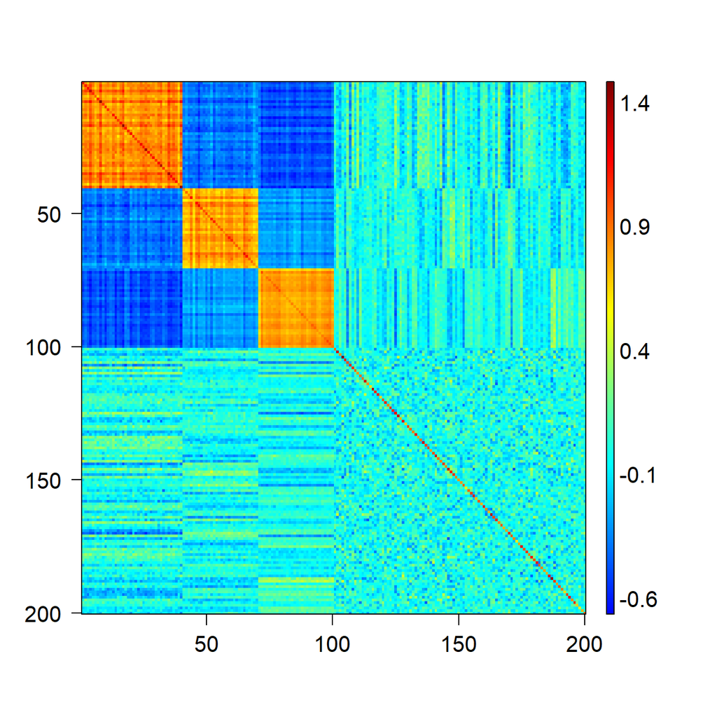

Figure D: the heatmap of the sample covariance matrix, based on the same dataset as in C, using the $K$-medoids method.

```r
plotMatrix(z = S_mat_est_kmeans, cex.axis = 1.3, cex.lab = 1.3, save.image = F)
```

```r
### heatmap of the sample covariance matrix based permuted covariates
```

The results of the $K$-medoids and SICERS methods are shown in Figures D and E, respectively. Both heatmaps D and E closely resemble the original structure in Figure B, indicating successful recovery of the underlying community structure.

```r
### applying ICON functions to data ###
set.seed(20254)
result_ICONS <- dense(S_perm_mat)
S_mat_est_ICONS <- result_ICONS$W_dense
### note that the diagonals are zero
diag(S_mat_est_ICONS) <- diag(S_perm_mat)[result_ICONS$Clist]
```

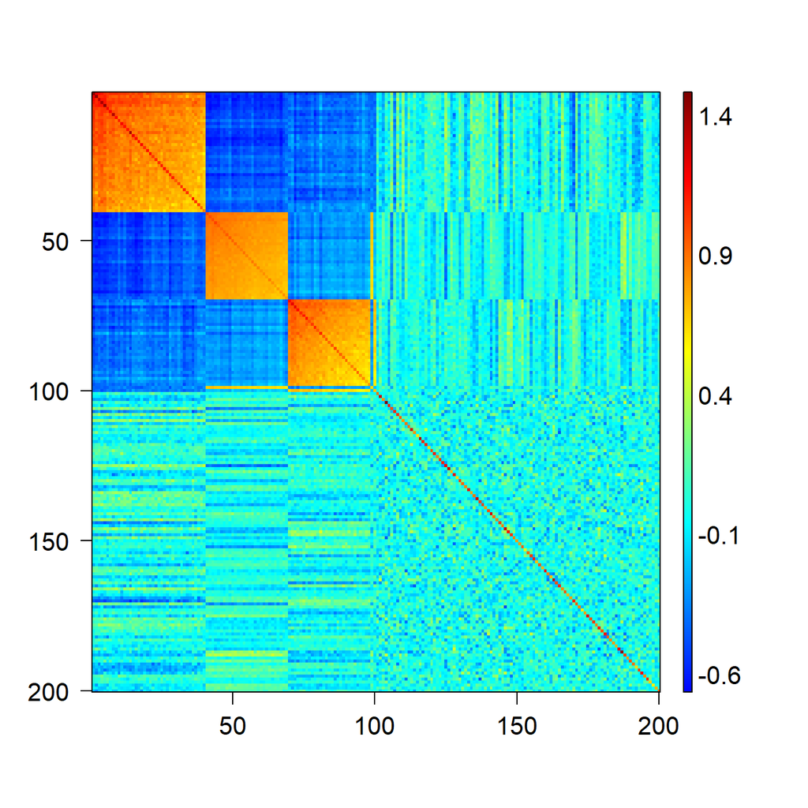

Figure E: the heatmap of the sample covariance matrix, based on the same dataset as in C, using the SICERS method.

```r
plotMatrix(z = S_mat_est_ICONS, cex.axis = 1.3, cex.lab = 1.3, save.image = F)
```

```r
### heatmap of the sample covariance matrix based permuted covariates
```